# floating pies in ggplot2

Ben Bolker

Floating pie charts are a challenge in `ggplot2`.

There are several Stack Overflow questions about this:

- https://stackoverflow.com/questions/9684371/create-floating-pie-charts-with-ggplot
- https://stackoverflow.com/questions/47718439/multiple-pies-with-scatterpie-or-ggforce

The `scatterpie` package and `ggforce::geom_arc_bar()` functions can do it, but **only with `coord_fixed`**; that is, the coordinates of the pie wedges are computed in the native x/y coordinates, so if the user actually wants circles they have to use coordinates where 1 x and 1 y unit correspond to equal physical distances in the plotting region.

This works OK if you want to plot pies on a map or in some other isotropic space. It’s a pain if you want to put floating pies into an arbitrary coordinate system. Three potential ways to do this are:

- (best?) write a new geom that sets up a viewport at the specified x/y location and plots a pie inside it, following a similar strategy to the [gridBase vignette](https://cran.r-project.org/web/packages/gridBase/vignettes/gridBase.pdf)
- write a version of `ggforce::geom_arc_bar()` that finds the local aspect ratio and corrects for it
- as below, construct individual pie charts and use (a hacked version of `annotation_custom()`) to insert them into the chart.

This follows these StackOverflow/blog posts:

- https://stackoverflow.com/questions/35532683/r-inserting-a-picture-into-faceted-ggplot-using-annotation-custom
- https://stackoverflow.com/questions/10673481/add-a-geom-layer-for-a-single-panel-in-a-faceted-plot
- https://clarewest.github.io/blog/post/2019-08-27-combining-inset-plots-with-facets-using-ggplot/

  and uses (hacked versions of) tools from the `ggimage` plot

```r
library(tidyverse)
library(gtools)  ## rdirichlet
library(ggplot2)
library(ggimage)
library(cowplot) ## get_legend, plot_grid
source("annotation.R")   ## hacked geom_subview/annotation_custom
## https://github.com/bbolker/bbmisc/blob/master/Rmisc/annotation.R
```

## Simulate some data

```r
rd <- function(n, alpha) {
    gtools::rdirichlet(n, alpha) |> as.data.frame() |> setNames(paste0("c", 1:length(alpha)))
}

## fake data
set.seed(101)
df <- (expand_grid(x = LETTERS[1:4],
                  f = letters[1:5])
    |> mutate(y = rgamma(length(x), scale = 3, shape = 5),
              s = rgamma(length(x), scale = 3, shape = 5))
    ## would like to use dynamic nrow(.data) but ?? (need %>% ?)
    |> bind_cols(rd(20, alpha = c(3,2,1)))
    |> mutate(across(where(is.character), factor))
)
```

## Function to construct a single pie chart from a one-row tibble

```r
pie_fun <- function(x, scale_fill = NULL, legend = FALSE) {
    ## FIXME: ensure matching levels for all pies?
    r <- (x
        |> pivot_longer(everything())
        |> ggplot(aes(x=1, y=value, fill = name)) +
           geom_bar(stat="identity", width=1) +
           coord_polar(theta="y") +
           theme_void() +
           theme_transparent()
    )
    if (!legend) {
        r <- r + theme(legend.position = "none")
    }
    if (!is.null(scale_fill)) {
        r <- r + scale_fill
    }
    return(r)
}
```

## Construct pie charts, extract legend

```r
dfpie <- (df
    |> tidyr::nest(data = c(c1, c2, c3))
    |> mutate(pie = map(data, pie_fun, scale_fill_brewer(palette="Dark2")))
    ## all mappings, factor/numeric conversion etc. must be done up front!
    ##  (geom_subview() does arithmetic directly on x, extracts mapped columns
    ##   from data **by name**)
    |> mutate(s = s/10, nx = as.numeric(x))
)
leg0 <- cowplot::get_legend(pie_fun(dfpie$data[[1]], scale_fill_brewer(palette="Dark2"),
                           legend = TRUE))
```

## Put the pieces together

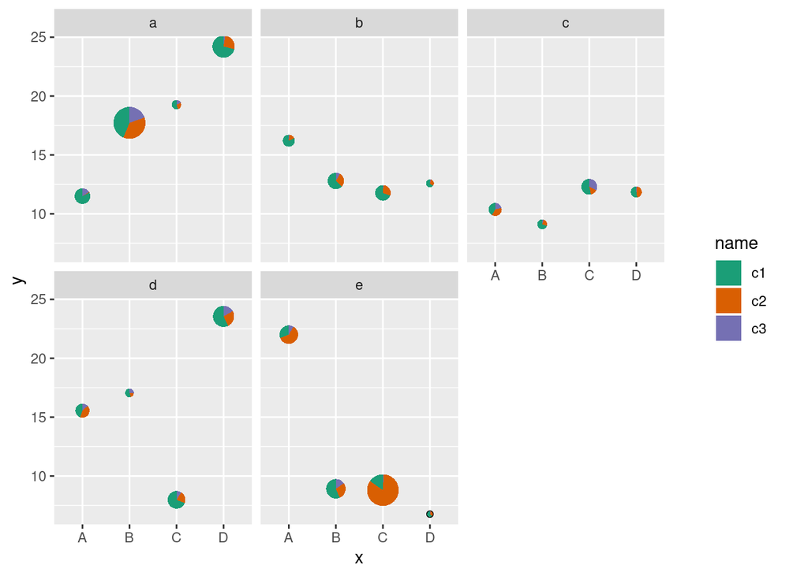

```r
## base plot
p <- p0 <- (ggplot(dfpie, aes(x=x, y=y))
    + geom_point()
    + facet_wrap(~f))
## add subviews
p <- (p
    + geom_subview(data = dfpie,
                   aes(x = nx,
                       y = y,
                       width = s,
                       height = s,
                       subview = pie)))
## add legend
plot_grid(p, leg0, ncol=2, rel_widths=c(1, 0.2))
```

- to do:
  - further encapsulation?
  - expand x/y limits appropriately (`annotation_custom` doesn’t do anything with limits)
  - in this example, legend could live in the empty panel space …
- It’s a bit weird that the panel info gets passed to `geom_subview` as the *original* variable, not as a variable called ‘panel’ or whatever (i.e. before ggdata processing) …